# Quels sont les déterminants individuels et comportementaux qui influencent le développement de symptômes depressifs ?

Edita AVDIC Inès BORDAIS Ophélie CHAUVEAU

# 1 Introduction

La dépression, en tant que trouble mental majeur, constitue un enjeu de santé publique mondial, particulièrement parmi les étudiants. En effet, cette tranche d’âge est souvent confrontée à de nombreux facteurs de stress, à la fois académiques, sociaux et personnels, qui peuvent influencer leur bien-être psychologique. Les symptômes dépressifs chez les étudiants sont donc le reflet d’une interaction complexe entre des déterminants individuels et comportementaux.

Les facteurs individuels, tels que l’âge, le sexe, ou les antécédents familiaux de troubles mentaux, peuvent avoir un impact direct sur la vulnérabilité à la dépression. Parallèlement, les comportements adoptés par les étudiants, qu’ils soient liés à leurs habitudes de sommeil, à leur alimentation, à leur gestion du stress ou encore à leur emploi du temps de travail et d’études, jouent également un rôle déterminant dans l’apparition et l’intensité des symptômes dépressifs.

Cette étude se concentre sur l’identification des variables influençant la dépression chez les étudiants, en prenant en compte les variables instrumentales et les variables omises. L’objectif est d’analyser l’impact de ces facteurs tout en contrôlant les biais potentiels liés à l’omission de certaines variables, afin de mieux comprendre les véritables déterminants de la dépression dans ce contexte.

Pour notre analyse, nous nous sommes appuyées sur une base de données accessible sur le site Kaggle résultant d’une enquête aléatoire et anonyme réalisée auprès d’étudiants indiens.

# 2 Comparaison de deux modèles

## 2.1 Modèle de regression initiale

Nous utiliserons un modèle de régression linéaire pour analyser les relations entre la dépression et un ensemble de facteurs individuels et comportementaux potentiellement influents. Les variables étudiées incluent le genre, l’âge, la pression académique, les habitudes alimentaires, les heures de travail/études, le stress financier et les antécédents familiaux de troubles mentaux.

Le modèle de régression linéaire suivant sera utilisé pour évaluer l’importance de chaque variable dans l’explication des symptômes dépressifs :

Depression = β0 + β1 genre + β2 Age + β3 pression académique + β4 habitudes alimentaires + β5 nombre d’heures étudiées + β6 stress financier + β7 antécédents familiaux de troubles mentaux + u

```
##
## Call:
## lm(formula = Depression ~ Gender + Age + Academic.Pressure +
##     Dietary.Habits + Work.Study.Hours + Financial.Stress + Family.History.of.Mental.Illness,
##     data = data)
##
## Residuals:
##      Min       1Q   Median       3Q      Max
## -1.27161 -0.28430  0.02976  0.29012  1.19939
##
## Coefficients:
##                                       Estimate Std. Error t value Pr(>|t|)
## (Intercept)                          0.1164389  0.0161978   7.189 6.71e-13 ***
## GenderMale                           0.0040855  0.0046895   0.871    0.384
## Age                                 -0.0159470  0.0004774 -33.402  < 2e-16 ***
## Academic.Pressure                    0.1411834  0.0017166  82.244  < 2e-16 ***
## Dietary.HabitsModerate               0.0824777  0.0059075  13.961  < 2e-16 ***
## Dietary.HabitsOthers                 0.2418013  0.1121057   2.157    0.031 *
## Dietary.HabitsUnhealthy              0.1661122  0.0059098  28.108  < 2e-16 ***
## Work.Study.Hours                     0.0186746  0.0006311  29.591  < 2e-16 ***
## Financial.Stress2.0                  0.0761059  0.0077033   9.880  < 2e-16 ***
## Financial.Stress3.0                  0.1969390  0.0076633  25.699  < 2e-16 ***
## Financial.Stress4.0                  0.2750166  0.0075082  36.629  < 2e-16 ***
## Financial.Stress5.0                  0.3577590  0.0073189  48.881  < 2e-16 ***
## Family.History.of.Mental.IllnessYes  0.0348159  0.0046537   7.481 7.58e-14 ***
## ---
## Signif. codes:  0 '***' 0.001 '**' 0.01 '*' 0.05 '.' 0.1 ' ' 1
##
## Residual standard error: 0.388 on 27885 degrees of freedom
##   (3 observations effacées parce que manquantes)
## Multiple R-squared:  0.3801, Adjusted R-squared:  0.3798
## F-statistic:  1425 on 12 and 27885 DF,  p-value: < 2.2e-16
```

## 2.2 Modèle de regression introduisant la variable “heures de sommeil”

Afin d’enrichir l’analyse des déterminants de la dépression, nous introduisons la variable « heures de sommeil » dans le modèle en tant que variable omise. Le sommeil étant reconnu comme un facteur essentiel de bien-être mental, il est pertinent d’examiner s’il joue un rôle significatif dans l’explication des symptômes dépressifs chez les individus. Cette variable permet d’évaluer l’impact de différentes durées de sommeil sur la probabilité de dépression, en complément des facteurs déjà considérés comme la pression académique, les habitudes alimentaires ou encore le stress financier. L’omission de cette variable pourrait limiter la précision du modèle, car le sommeil pourrait influencer la dépression de manière significative, sans avoir été pris en compte dans l’analyse initiale.

Le modèle de régression linéaire suivant sera utilisé pour évaluer l’importance de chaque variable dans l’explication des symptômes dépressifs : Depression = β0 + β1 genre + β2 Age + β3 pression académique + β4 habitudes alimentaires + β5 nombre d’heures étudiées + β6 stress financier + β7 antécédents familiaux de troubles mentaux + β8 nombre d’heures de sommeil + u

```
##
## Call:
## lm(formula = Depression ~ Gender + Age + Academic.Pressure +
##     Dietary.Habits + Work.Study.Hours + Financial.Stress + Family.History.of.Mental.Illness +
##     Sleep.Duration, data = data)
##
## Residuals:
##      Min       1Q   Median       3Q      Max
## -1.27123 -0.27992  0.02865  0.28856  1.20567
##
## Coefficients:
##                                       Estimate Std. Error t value Pr(>|t|)
## (Intercept)                          0.1122919  0.0167587   6.701 2.12e-11 ***
## GenderMale                           0.0039491  0.0046706   0.846   0.3978
## Age                                 -0.0159633  0.0004755 -33.571  < 2e-16 ***
## Academic.Pressure                    0.1400576  0.0017112  81.848  < 2e-16 ***
## Dietary.HabitsModerate               0.0816789  0.0058839  13.882  < 2e-16 ***
## Dietary.HabitsOthers                 0.2285288  0.1116454   2.047   0.0407 *
## Dietary.HabitsUnhealthy              0.1659258  0.0058865  28.187  < 2e-16 ***
## Work.Study.Hours                     0.0184193  0.0006291  29.280  < 2e-16 ***
## Financial.Stress2.0                  0.0789551  0.0076752  10.287  < 2e-16 ***
## Financial.Stress3.0                  0.1988792  0.0076340  26.052  < 2e-16 ***
## Financial.Stress4.0                  0.2767543  0.0074811  36.994  < 2e-16 ***
## Financial.Stress5.0                  0.3581283  0.0072892  49.132  < 2e-16 ***
## Family.History.of.Mental.IllnessYes  0.0343235  0.0046348   7.406 1.34e-13 ***
## Sleep.Duration7-8 hours              0.0129738  0.0066717   1.945   0.0518 .
## Sleep.DurationLess than 5 hours      0.0533437  0.0064995   8.207 2.36e-16 ***
## Sleep.DurationMore than 8 hours     -0.0462365  0.0069979  -6.607 3.99e-11 ***
## Sleep.DurationOthers                -0.0192369  0.0912089  -0.211   0.8330
## ---
## Signif. codes:  0 '***' 0.001 '**' 0.01 '*' 0.05 '.' 0.1 ' ' 1
##
## Residual standard error: 0.3864 on 27881 degrees of freedom
##   (3 observations effacées parce que manquantes)
## Multiple R-squared:  0.3853, Adjusted R-squared:  0.3849
## F-statistic:  1092 on 16 and 27881 DF,  p-value: < 2.2e-16
```

L’ajout de la variable « heures de sommeil » améliore légèrement la qualité explicative du modèle, avec un R² ajusté passant de 0.3798 à 0.3849. La significativité globale reste très forte (p < 2.2e-16), indiquant que l’ensemble des variables explique bien la dépression. Parmi les nouvelles modalités introduites, le fait de dormir «moins de 5 heures» est fortement associé à une hausse de la dépression (p < 0.001), tandis que «plus de 8 heures» est lié à une baisse significative. Les autres variables précédemment significatives le restent, confirmant la robustesse du modèle élargi.

|  | Res.Df | RSS | Df | Sum of Sq | F | Pr(>F) |
| --- | --- | --- | --- | --- | --- | --- |
| 1 | 27885 | 4197.245 | NA | NA | NA | NA |
| 2 | 27881 | 4161.976 | 4 | 35.26876 | 59.06619 | 9.645301e-50 |

La comparaison des deux modèles montre que l’ajout de la variable Sleep.Duration améliore significativement l’explication de la dépression (F = 59.07, p < 0.001). Cette différence indique que le second modèle, qui inclut la durée de sommeil, explique mieux la variabilité de la dépression que le premier. Ainsi, le sommeil apparaît comme un facteur pertinent à considérer dans l’analyse des symptômes dépressifs.

## 2.3 Analyse de l’effet marginal du sommeil

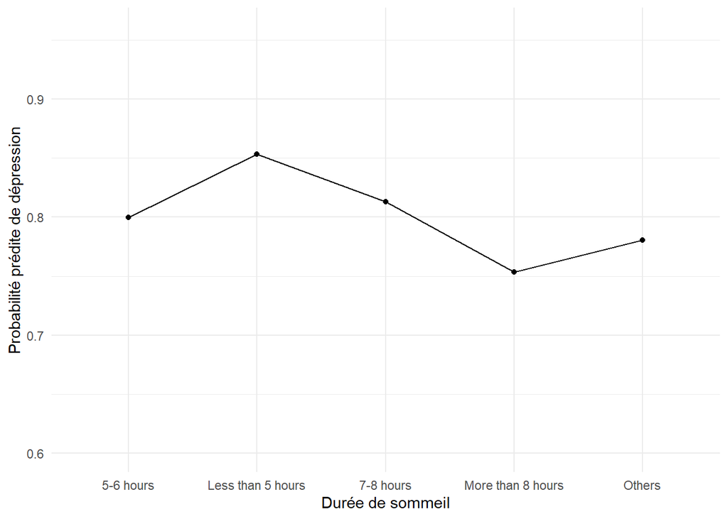

Les résultats mettent en évidence des variations dans la probabilité de dépression selon la durée de sommeil :

“Moins de 5 heures” (0,85) : Ce groupe présente la probabilité la plus élevée de dépression, suggérant qu’un sommeil très court est fortement associé à un risque accru de symptômes dépressifs. “7-8 heures” (0,82) : Bien que cette plage horaire soit généralement considérée comme optimale, elle reste associée à une probabilité relativement élevée de dépression, quoique inférieure à celle des moins de 5 heures. “Plus de 8 heures” (0,75) : Les individus dormant plus de 8 heures présentent une probabilité de dépression plus faible, ce qui pourrait refléter un effet protecteur d’un sommeil prolongé. “Autre” (0,78) : Cette catégorie, qui regroupe les cas atypiques, présente une probabilité modérément élevée, mais inférieure à celle des courtes durées de sommeil. Ces écarts suggèrent qu’un sommeil insuffisant est associé à un risque accru de dépression, tandis qu’un sommeil plus long semble exercer un effet bénéfique sur la santé mentale.

Afin d’évaluer l’impact de la durée de sommeil sur les symptômes dépressifs, nous avons choisi de prédire la probabilité de dépression en fonction des différentes plages horaires de sommeil, tout en contrôlant les autres variables du modèle. Cette approche permet de visualiser clairement l’influence de la durée de sommeil sur la dépression. Le graphique obtenu offre une représentation intuitive de cette relation, facilitant ainsi la compréhension de l’effet potentiel du sommeil sur la santé mentale.

# 3 Détection de l’hétéroscédasticité

## 3.1 Test de Breusch-Pagan

A l’aide d’un test de Breusch-Pagan, nous allons observer s’il y a un problème d’hétéroscédasticité dans le modèle. Si effectivement il y en a un, nous allons corriger les erreurs standards.

Nous posons les hypothèses suivantes :

- Hypothèse 0 : Le modèle contrait c’est-à-dire qu’il y a homoscédasticité : la variance des erreurs est constante quelque soit les variables explicatives.
- Hypothèse 1 : Le modèle non-contrait c’est-à-dire qu’il y a hétéroscédasticité : la variance des erreurs est différente selon les variables explicatives.

```
##
##  studentized Breusch-Pagan test
##
## data:  modele
## BP = 467.25, df = 12, p-value < 2.2e-16
```

Ici, la p_value est inférieur à 0.05, on conserve l’hypothèse H1 selon laquelle il y a un problème d’hétéroscédasticité.

## 3.2 Corriger l’hétéroscédasticité

De ce fait, pour tenir compte de l’hétéroscédasticité, nous allons utiliser la méthode de White (HC1) pour corriger les erreurs standards et produire des estimateurs robustes.

```
##
## t test of coefficients:
##
##                                        Estimate  Std. Error  t value  Pr(>|t|)
## (Intercept)                          0.11643886  0.01636218   7.1163 1.135e-12
## GenderMale                           0.00408550  0.00468541   0.8720   0.38324
## Age                                 -0.01594703  0.00047727 -33.4131 < 2.2e-16
## Academic.Pressure                    0.14118337  0.00170011  83.0437 < 2.2e-16
## Dietary.HabitsModerate               0.08247773  0.00606718  13.5941 < 2.2e-16
## Dietary.HabitsOthers                 0.24180127  0.11147393   2.1691   0.03008
## Dietary.HabitsUnhealthy              0.16611215  0.00602331  27.5782 < 2.2e-16
## Work.Study.Hours                     0.01867456  0.00063987  29.1848 < 2.2e-16
## Financial.Stress2.0                  0.07610589  0.00799092   9.5240 < 2.2e-16
## Financial.Stress3.0                  0.19693904  0.00802938  24.5273 < 2.2e-16
## Financial.Stress4.0                  0.27501656  0.00779398  35.2858 < 2.2e-16
## Financial.Stress5.0                  0.35775902  0.00736575  48.5706 < 2.2e-16
## Family.History.of.Mental.IllnessYes  0.03481588  0.00465291   7.4826 7.501e-14
##
## (Intercept)                         ***
## GenderMale
## Age                                 ***
## Academic.Pressure                   ***
## Dietary.HabitsModerate              ***
## Dietary.HabitsOthers                *
## Dietary.HabitsUnhealthy             ***
## Work.Study.Hours                    ***
## Financial.Stress2.0                 ***
## Financial.Stress3.0                 ***
## Financial.Stress4.0                 ***
## Financial.Stress5.0                 ***
## Family.History.of.Mental.IllnessYes ***
## ---
## Signif. codes:  0 '***' 0.001 '**' 0.01 '*' 0.05 '.' 0.1 ' ' 1
```

```
##
## Call:
## lm(formula = Depression ~ Gender + Age + Academic.Pressure +
##     Dietary.Habits + Work.Study.Hours + Financial.Stress + Family.History.of.Mental.Illness,
##     data = data)
##
## Residuals:
##      Min       1Q   Median       3Q      Max
## -1.27161 -0.28430  0.02976  0.29012  1.19939
##
## Coefficients:
##                                       Estimate Std. Error t value Pr(>|t|)
## (Intercept)                          0.1164389  0.0161978   7.189 6.71e-13 ***
## GenderMale                           0.0040855  0.0046895   0.871    0.384
## Age                                 -0.0159470  0.0004774 -33.402  < 2e-16 ***
## Academic.Pressure                    0.1411834  0.0017166  82.244  < 2e-16 ***
## Dietary.HabitsModerate               0.0824777  0.0059075  13.961  < 2e-16 ***
## Dietary.HabitsOthers                 0.2418013  0.1121057   2.157    0.031 *
## Dietary.HabitsUnhealthy              0.1661122  0.0059098  28.108  < 2e-16 ***
## Work.Study.Hours                     0.0186746  0.0006311  29.591  < 2e-16 ***
## Financial.Stress2.0                  0.0761059  0.0077033   9.880  < 2e-16 ***
## Financial.Stress3.0                  0.1969390  0.0076633  25.699  < 2e-16 ***
## Financial.Stress4.0                  0.2750166  0.0075082  36.629  < 2e-16 ***
## Financial.Stress5.0                  0.3577590  0.0073189  48.881  < 2e-16 ***
## Family.History.of.Mental.IllnessYes  0.0348159  0.0046537   7.481 7.58e-14 ***
## ---
## Signif. codes:  0 '***' 0.001 '**' 0.01 '*' 0.05 '.' 0.1 ' ' 1
##
## Residual standard error: 0.388 on 27885 degrees of freedom
##   (3 observations effacées parce que manquantes)
## Multiple R-squared:  0.3801, Adjusted R-squared:  0.3798
## F-statistic:  1425 on 12 and 27885 DF,  p-value: < 2.2e-16
```

En comparant les erreurs standards classiques et robustes, on constate que les écarts sont minimes. Et la significativité des variables ne changent pas. Cela peut s’expliquer, d’une part, par la taille de l’échantillon qui est plutôt grande, qui rend les erreurs standards plus stables. Et d’autre part, par une spécification correcte du modèle. Cependant, l’utilisation d’une correction robuste est utile pour garantir la fiabilité des tests.

## 3.3 Source de l’hétéroscédasticité

Nous pouvons maintenant essayer de trouver une variable qui explique le problème d’hétéroscédasticité. La variable “Age” pourrait expliquer ce problème si elle a une relation non-linéaire avec la variance des erreurs.

On peut d’abord tester cette hypothèse par un test de Breusch-Pagan :

- Hypothèse 0 : Il n’y a pas de problème d’hétéroscédasticité dans le modèle, la variance des erreurs est constante.
- Hypothèse 1 : Il y a un problème d’hétéroscédasticité, la variance des erreurs change en fonction de Age.

```
##
##  studentized Breusch-Pagan test
##
## data:  modele
## BP = 50.724, df = 1, p-value = 1.063e-12
```

Le test est significatif puisqu’il est inférieur à 0.05 c’est-à-dire que la variance des résidus varie en fonction de l’âge. Le test de Breusch-Pagan réalisé avec la variable explicative Age est significatif, ce qui indique que la variance des résidus n’est pas constante en fonction de l’âge. Ce constat suggère une relation potentiellement non linéaire entre l’âge et la depression.

# 4 L’effet de l’âge et des habitudes alimentaires sur la dépression

## 4.1 Relation non linéaire entre l’âge et la dépression

Comme vu précédamment, l’Age semble avoir une relation non linéaire avec la dépression. Nous allons donc ajouter la varaible “Age” au carré. Le but étant d’améliorer la capacité du modèle à prédire et à expliquer la dépression en fonction de l’âge.

```
##
## Call:
## lm(formula = Depression ~ Gender + Age + Age2 + Academic.Pressure +
##     Dietary.Habits + Work.Study.Hours + Financial.Stress + Family.History.of.Mental.Illness,
##     data = data)
##
## Residuals:
##      Min       1Q   Median       3Q      Max
## -1.26191 -0.28289  0.02976  0.28853  1.19848
##
## Coefficients:
##                                       Estimate Std. Error t value Pr(>|t|)
## (Intercept)                         -3.328e-01  6.173e-02  -5.392 7.02e-08 ***
## GenderMale                           4.098e-03  4.685e-03   0.875    0.382
## Age                                  1.973e-02  4.755e-03   4.150 3.33e-05 ***
## Age2                                -6.824e-04  9.048e-05  -7.542 4.76e-14 ***
## Academic.Pressure                    1.412e-01  1.715e-03  82.328  < 2e-16 ***
## Dietary.HabitsModerate               8.237e-02  5.902e-03  13.957  < 2e-16 ***
## Dietary.HabitsOthers                 2.416e-01  1.120e-01   2.158    0.031 *
## Dietary.HabitsUnhealthy              1.655e-01  5.904e-03  28.036  < 2e-16 ***
## Work.Study.Hours                     1.864e-02  6.305e-04  29.566  < 2e-16 ***
## Financial.Stress2.0                  7.564e-02  7.696e-03   9.829  < 2e-16 ***
## Financial.Stress3.0                  1.967e-01  7.656e-03  25.693  < 2e-16 ***
## Financial.Stress4.0                  2.748e-01  7.501e-03  36.633  < 2e-16 ***
## Financial.Stress5.0                  3.572e-01  7.312e-03  48.857  < 2e-16 ***
## Family.History.of.Mental.IllnessYes  3.523e-02  4.649e-03   7.577 3.64e-14 ***
## ---
## Signif. codes:  0 '***' 0.001 '**' 0.01 '*' 0.05 '.' 0.1 ' ' 1
##
## Residual standard error: 0.3876 on 27884 degrees of freedom
##   (3 observations effacées parce que manquantes)
## Multiple R-squared:  0.3813, Adjusted R-squared:  0.381
## F-statistic:  1322 on 13 and 27884 DF,  p-value: < 2.2e-16
```

Ce tableau nous montre que l’ajout de la variable Age2 dans le modèle permet de mieux capter la relation entre l’âge et la dépression. Les résultats montrent que les deux coefficients Age et Age2 sont significatifs. L’Age2 ayant un coefficient négatif, la relation entre la depression et l’age est une courbe en U inversé : la dépression augmente avec l’âge jusqu’à un certain point, puis commence à diminuer à un certain âge.

De plus, si on compare le R² ajusté du modèle avec et sans l’Age2, on constate que l’ajout de Age2 permet d’expliquer mieux la dépression et d’améliorer le modèle : 0.3798 < 0.381.

## 4.2 Intéraction entre l’age et les habitudes alimentaires sur la dépression

On va maintenant faire une régression afin d’observer l’impact de l’âge sur les habitudes alimentaires.

```
##
## Call:
## lm(formula = Depression ~ Age * Dietary.Habits, data = data)
##
## Residuals:
##     Min      1Q  Median      3Q     Max
## -0.8531 -0.4960  0.2255  0.3962  1.0263
##
## Coefficients:
##                              Estimate Std. Error t value Pr(>|t|)
## (Intercept)                  1.084023   0.028816  37.619  < 2e-16 ***
## Age                         -0.024137   0.001084 -22.257  < 2e-16 ***
## Dietary.HabitsModerate       0.037698   0.038363   0.983  0.32578
## Dietary.HabitsOthers        -1.839967   0.741199  -2.482  0.01306 *
## Dietary.HabitsUnhealthy      0.122663   0.038075   3.222  0.00128 **
## Age:Dietary.HabitsModerate   0.002559   0.001446   1.770  0.07674 .
## Age:Dietary.HabitsOthers     0.077990   0.027583   2.827  0.00470 **
## Age:Dietary.HabitsUnhealthy  0.004491   0.001450   3.098  0.00195 **
## ---
## Signif. codes:  0 '***' 0.001 '**' 0.01 '*' 0.05 '.' 0.1 ' ' 1
##
## Residual standard error: 0.4701 on 27893 degrees of freedom
## Multiple R-squared:  0.08963,    Adjusted R-squared:  0.0894
## F-statistic: 392.3 on 7 and 27893 DF,  p-value: < 2.2e-16
```

Ce modèle nous permet d’analyser à la fois l’effet de l’âge seul, celui de chaque modalité des habitudes alimentaires (comparées à la catégorie de référence “Healthy”), ainsi que l’effet combiné entre l’âge et chaque type d’habitude alimentaire sur le score de dépression.

Effet de l’âge seul : Le coefficient de l’âge est négatif et très significatif (p < 2e-16). Cela signifie que chaque année supplémentaire est associée à une baisse de 0,024 point du score de dépression, chez les étudiants ayant une alimentation saine. Autrement dit, chez ces individus, l’âge semble avoir un effet protecteur contre la dépression.

Effet des habitudes alimentaires seules : L’habitude alimentaire « Modérée » n’est pas significative (p = 0.326), elle n’a donc pas d’impact direct sur la dépression.

En revanche : Les étudiants ayant sélectionné la catégorie « Others » présentent un score de dépression significativement plus faible que ceux ayant une alimentation saine (coef = -1.840, p = 0.013, significatif), on peut donc dire que si l’alimentation dite others augmente alors la dépression baisse.

Les étudiants avec une alimentation malsaine (« Unhealthy ») présentent un score significativement plus élevé (coef = 0.123, p = 0.001, très significatif). En effet, plus on a des habitudes malsaines, plus le score de la dépression augmente.

Ces résultats suggèrent que des habitudes alimentaires malsaines augmentent le score de dépression, tandis que certaines catégories alternatives (comme “Others”) pourraient être associées à une meilleure santé mentale. Cela peut s’expliquer par des régimes particuliers (végétariens, culturels, religieux, etc.) qui sont équilibrés mais ne sont pas perçus comme “healthy” par les répondants eux-mêmes.

Effet des interactions âge × habitudes alimentaires :

L’effet protecteur de l’âge varie selon le type d’alimentation :

Pour les étudiants ayant coché « Others », l’interaction est significative et positive (coef = 0.078, p = 0.0047), ce qui signifie que l’effet protecteur de l’âge est inversé : plus l’âge augmente, plus le score de dépression augmente dans ce groupe.

Chez les étudiants ayant une alimentation malsaine, l’effet de l’âge est très atténué (coef = 0.0045, p = 0.0019, ce qui est significatif), ce qui suggère que l’âge protège beaucoup moins dans ce groupe.

De plus, on peut souligner que le modèle est globalement significatif ; on le voit avec la F-statistique, c’est-à-dire qu’au moins une variable du modèle est significativement liée à la dépression.

Conclusion générale : Ces résultats suggèrent que le vieillissement, pris isolément, ne constitue pas une protection systématique contre la dépression chez les étudiants. L’hygiène de vie, et en particulier les habitudes alimentaires, joue un rôle modérateur essentiel : elle peut renforcer, atténuer voire inverser l’effet de l’âge. Cela souligne l’importance d’intégrer les comportements de santé dans les politiques de prévention en santé mentale, en particulier à destination des jeunes adultes.

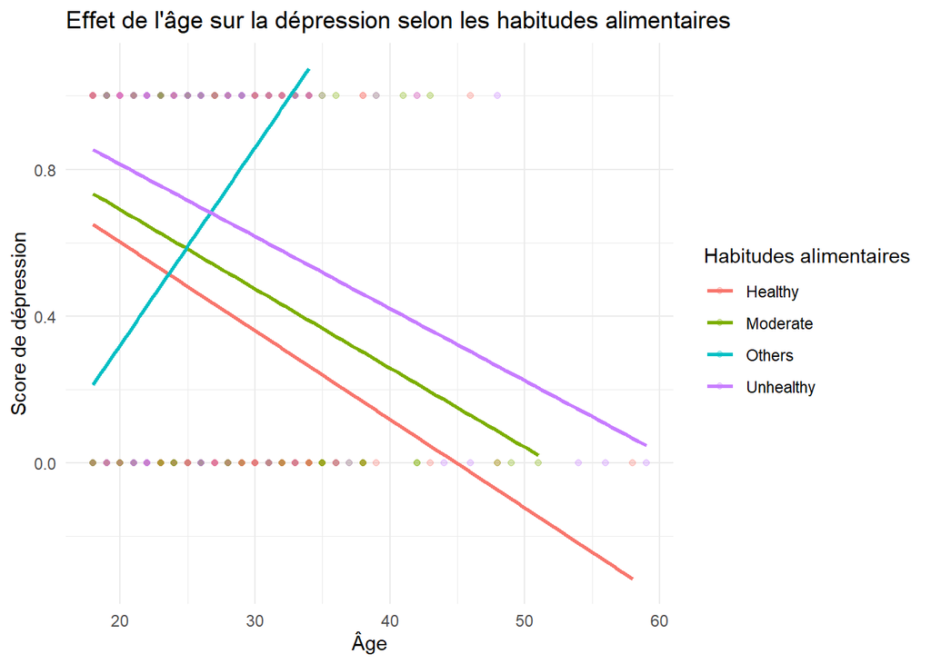

Sur ce graphique chaque courbe représente une relation différente entre l’âge et la dépression, selon les habitudes alimentaires. On voit que la pente est décroissante pour certains groupes : exemple pour “healthy” l’âge protège de la dépression. Mais la pente peut aussi être croissante : exemple pour “Others” à mesure que l’âge augmente le score de dépression augmente.

# 5 Problème d’endogénéité

Cependant, nous soupçonnons ici que la variable “Study.time” (le temps de révision) est endogène dans l’explication de la dépression, car le temps de révision peut être influencé par des variables non observées comme la motivation, ou être lui-même influencé par la dépression. En effet, un étudiant dépressif révise moins, mais ne pas réviser peut aussi augmenter la dépression, ce qui donne un biais d’endogénéité.

C’est pourquoi nous allons utiliser une variable instrumentale pour Study.time. Pour cela, il faut que l’instrument remplisse la condition de pertinence (être corrélé avec Study.time directement) et d’exclusion (ne pas influencer directement la dépression, sauf via Study.time).

Nous allons donc utiliser Study.Satisfaction, car elle influence logiquement le temps de révision (plus je suis satisfait de mes études, plus je révise), et elle n’agit pas directement sur la dépression, sauf via le travail scolaire fourni (si je travaille trop, cela peut plonger un individu dans une dépression, et ne pas assez travailler et recevoir de mauvaises notes peut aussi impacter l’état de santé mentale).

Maintenant on va verifier si Study.Satisfaction est bien corélée avec Study.Time

```
##
## Call:
## lm(formula = Work.Study.Hours ~ Study.Satisfaction, data = data)
##
## Residuals:
##     Min      1Q  Median      3Q     Max
## -7.4492 -3.0521  0.7493  2.9479  5.0471
##
## Coefficients:
##                    Estimate Std. Error t value Pr(>|t|)
## (Intercept)         7.44920    0.05286 140.934  < 2e-16 ***
## Study.Satisfaction -0.09926    0.01630  -6.091 1.14e-09 ***
## ---
## Signif. codes:  0 '***' 0.001 '**' 0.01 '*' 0.05 '.' 0.1 ' ' 1
##
## Residual standard error: 3.705 on 27899 degrees of freedom
## Multiple R-squared:  0.001328,   Adjusted R-squared:  0.001292
## F-statistic:  37.1 on 1 and 27899 DF,  p-value: 1.138e-09
```

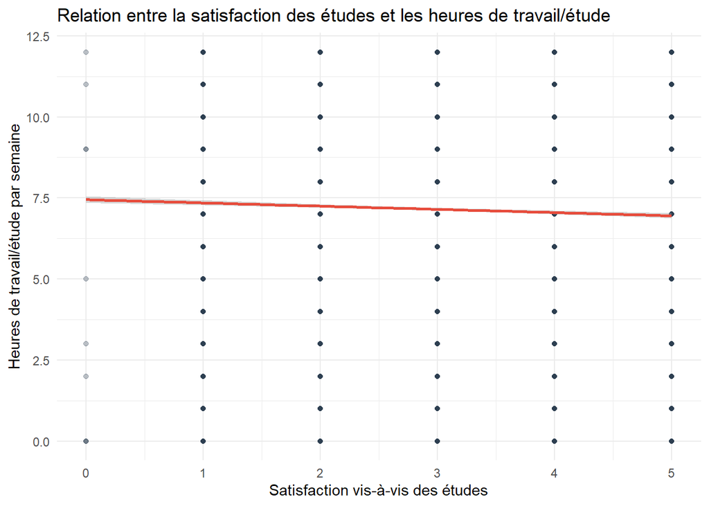

Le graphique nous illustre bien nos résultats précédent et nous indique une droite décroissante ce qui nous montre que plus la satisfaction par rapport aux études augmente moins les étudiants déclarent passer d’heures à étudier.

les résultats de la régression au dessus nous l’ont bien indiqués car le coefficient de study satisfaction est négatif cela veut dire que à mesure que la satisfaction pour nos études augmente moins on travail ce qui est assez cohérent. En effet si on aime nos études on aura potentiellement plus de facilité à comprendre en cours et donc on aurait moins de travail à la maison. la p-value est très significative ce qui nous indique que Study.Satisfaction influence directement le temps passer à étudier (condition de pertinence validée).

Nous supposons que la satisfaction académique n’influence la dépression que par son effet sur le temps de travail. Un étudiant satisfait gère généralement mieux son travail, ce qui affecte son exposition au stress ou à la fatigue. Ainsi, c’est le comportement d’étude et non la satisfaction elle-même qui impacte l’état psychologique. Cette hypothèse justifie l’utilisation de Study Satisfaction comme variable instrumentale pour Work/Study Hours (condition d’exclusion validée).

La question qui se pose maintenant est : est-ce que le temps de travail influence la dépression chez les étudiants ?

```
##
## Call:
## ivreg(formula = Depression ~ Work.Study.Hours | Study.Satisfaction,
##     data = data)
##
## Residuals:
##     Min      1Q  Median      3Q     Max
## -3.5516 -1.9392 -0.4894  1.7356  4.7978
##
## Coefficients:
##                  Estimate Std. Error t value Pr(>|t|)
## (Intercept)      -3.79785    0.70445  -5.391 7.06e-08 ***
## Work.Study.Hours  0.61246    0.09841   6.223 4.93e-10 ***
## ---
## Signif. codes:  0 '***' 0.001 '**' 0.01 '*' 0.05 '.' 0.1 ' ' 1
##
## Residual standard error: 2.221 on 27899 degrees of freedom
## Multiple R-Squared: -19.32,  Adjusted R-squared: -19.32
## Wald test: 38.73 on 1 and 27899 DF,  p-value: 4.933e-10
```

Les résultats nous indiquent que chaque heure supplémentaire de temps de travail à étudier est associée à une augmentation de 0,61 point du score de dépression, lorsqu’on corrige le biais d’endogénéité avec la satisfaction académique. Ce résultat suggère que l’intensité du travail est un facteur qui peut aggraver les symptômes dépressifs chez les étudiants. Le modèle est globalement significatif, on le voit avec la p-value très petite (p = 4.933e-10). Ce résultat souligne l’importance de considérer la qualité du travail, et non seulement sa quantité, dans les politiques de prévention en santé mentale étudiante.

Comparons ces résultats avec une régression classique :

```
##
## Call:
## lm(formula = Depression ~ Work.Study.Hours, data = data)
##
## Residuals:
##     Min      1Q  Median      3Q     Max
## -0.7197 -0.5257  0.3080  0.3911  0.6128
##
## Coefficients:
##                  Estimate Std. Error t value Pr(>|t|)
## (Intercept)      0.387162   0.006271   61.74   <2e-16 ***
## Work.Study.Hours 0.027712   0.000778   35.62   <2e-16 ***
## ---
## Signif. codes:  0 '***' 0.001 '**' 0.01 '*' 0.05 '.' 0.1 ' ' 1
##
## Residual standard error: 0.4818 on 27899 degrees of freedom
## Multiple R-squared:  0.0435, Adjusted R-squared:  0.04346
## F-statistic:  1269 on 1 and 27899 DF,  p-value: < 2.2e-16
```

On remarque que dans le modèle classique, chaque heure de travail supplémentaire augmente légèrement la dépression (coef = 0.028). Dans le modèle instrumental, cet effet est plus fort (coef = 0.61), cela nous prouve l’intérêt de la variable instrumentale.

Ainsi, le modèle classique sous-estime l’effet réel du temps de travail sur la dépression, car il y a probablement des étudiants très dépressifs qui travaillent peu, ou encore des facteurs non observés comme la pression ou la motivation. C’est pourquoi le modèle instrumental est intéressant : il isole l’effet “pur” du temps de travail, via la satisfaction académique, ce qui révèle un effet nettement plus important.

Donc, le surtravail peut être un facteur aggravant de la dépression chez les étudiants, et les modèles classiques peuvent sous-estimer cette réalité.

Et vu que les illustrations sont mieux, voici un graphique !

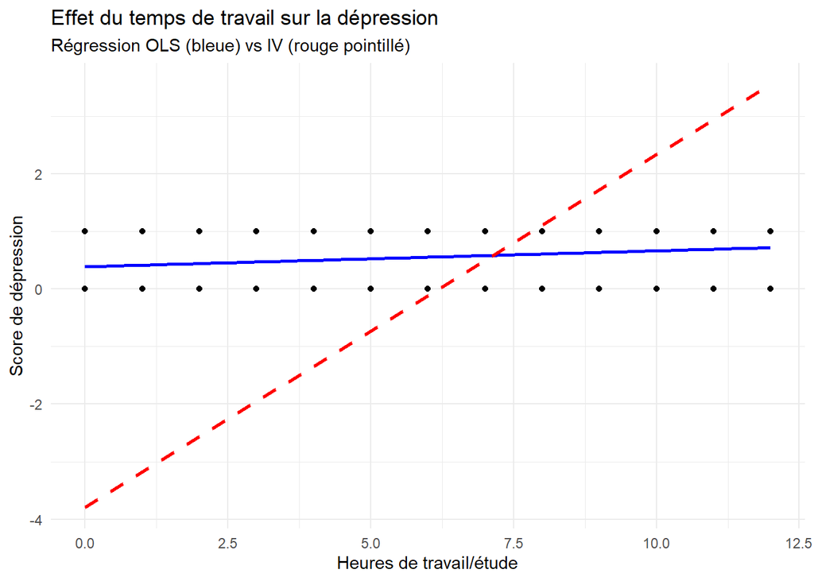

Ce graphique illustre l’effet du temps de travail sur la dépression chez les étudiants, comparé entre une régression classique (modele_ols) et une régression avec variable instrumentale (modele_vi). La droite bleue (OLS) montre une relation positive modérée, tandis que la droite rouge pointillée (vi), corrigée du biais d’endogénéité grâce à la satisfaction académique, révèle un effet nettement plus fort. Cela suggère que le surtravail, lorsqu’il n’est pas ajusté pour des facteurs comme la satisfaction ou la motivation, peut sous-estimer son impact réel sur la santé mentale. L’approche par variable instrumentale permet ainsi une estimation plus crédible de l’effet causal du travail intensif sur les symptômes dépressifs.

# 6 Conclusion

L’étude de plusieurs modèles de regression linéaire nous a permis de comprendre les déterminants de la dépression chez les étudiants. Dans un premier temps, l’introduction de la variable « heures de sommeil » a permis d’améliorer significativement la qualité du modèle en démontrant le rôle crucial du sommeil dans la santé mentale.

En parallèle, les tests d’hétéroscédasticité ont mis en évidence une variabilité non constante des erreurs, notamment en fonction de l’âge. Cela a nécessité l’ajustement du modèle par des erreurs standards robustes pour garantir la fiabilité des résultats.

Par ailleurs, l’analyse de la relation entre l’âge et la dépression a révélé une forme non linéaire en U inversé, suggérant que le risque de dépression augmente avec l’âge jusqu’à un certain seuil, avant de diminuer. Cette dynamique est toutefois fortement influencée par les habitudes alimentaires. En effet, les interactions entre l’âge et le type d’alimentation montrent que les effets de l’âge sur la santé mentale dépendent du mode de vie..

Enfin, l’approche par variable instrumentale a permis de corriger le biais d’endogénéité affectant la variable « heures de travail/étude ». Les résultats issus de cette méthode révèlent un effet bien plus fort du surtravail sur les symptômes dépressifs que celui estimé par une régression classique. Cela indique que la surcharge académique est un facteur de risque sous-estimé si l’on ne prend pas en compte les mécanismes causaux sous-jacents.

Au final, cette étude confirme que la dépression chez les étudiants est un phénomène qui dépend de beaucoup de facteurs, influencé par des éléments individuels (âge, antécédents familiaux), comportementaux (alimentation, sommeil, charge de travail), mais aussi par des interactions complexes entre ces facteurs.

Ces résultats montre qu’une prévention active, un accompagnement psychologique et un mode de vie équilibré est nécessaire pour préserver la santé mentale des étudiants.